# Student Performance: A Reproducible Statistical Report

*Generated automatically on 2026-10-19 with Python 3.13.16, pandas 3.0.5, scipy 1.18.1, statsmodels 0.15.0. Random seed = 4131.*

## 1. Objective

Investigate which factors influence exam performance among 300 students and whether teaching method matters.

## 2. Data

`data/students.csv` (synthetic, generated by `data/generate_datasets.py`). 11 variables, no missing values.

### Descriptive statistics

|  | count | mean | std | min | 25% | 50% | 75% | max |
| --- | --- | --- | --- | --- | --- | --- | --- | --- |
| study_hours | 300 | 12.11 | 4.21 | 2.9 | 9 | 12.1 | 15.2 | 22.9 |
| attendance_pct | 300 | 87.82 | 7.12 | 62.5 | 83.45 | 89.05 | 93 | 99.7 |
| sleep_hours | 300 | 7 | 0.96 | 4 | 6.4 | 7 | 7.6 | 9.5 |
| prior_gpa | 300 | 3.06 | 0.52 | 1.5 | 2.71 | 3.09 | 3.45 | 4 |
| exam_score | 300 | 61.53 | 10.24 | 25.7 | 55.15 | 61.8 | 68.72 | 87.6 |

### Exam score by teaching method

| method | count | mean | std |
| --- | --- | --- | --- |
| A | 89 | 58.39 | 10.3 |
| B | 123 | 60.48 | 9.06 |
| C | 88 | 66.17 | 10.24 |

## 3. Methods

One-way ANOVA (method effect), Pearson correlation (study hours), and multiple linear regression (OLS) with study hours, attendance, prior GPA and method as predictors. Significance level 0.05.

## 4. Results

- **ANOVA:** F = 15.17, p = 5.3e-07
- **Correlation (study hours, score):** r = 0.708, p = 5.4e-47
- **Regression:** R² = 0.641, adjusted R² = 0.635

### Regression coefficients

|  | estimate | std_err | t | p_value |
| --- | --- | --- | --- | --- |
| Intercept | 7.5236 | 5.0513 | 1.4894 | 0.1374 |
| C(method)[T.B] | 3.4315 | 0.8664 | 3.9604 | 0.0001 |
| C(method)[T.C] | 7.4485 | 0.9324 | 7.989 | 0 |
| study_hours | 1.6906 | 0.0853 | 19.8079 | 0 |
| attendance_pct | 0.1897 | 0.0503 | 3.7724 | 0.0002 |
| prior_gpa | 4.3334 | 0.6868 | 6.3094 | 0 |

## 5. Conclusions

1. Teaching method matters: mean scores differ significantly across methods (p = 5.3e-07).
2. Study hours is the strongest single predictor (r = 0.71); each extra hour adds about 1.69 marks, controlling for the other factors.
3. The model explains 64% of score variation; the remainder is individual variation not measured here.
4. The data are synthetic: conclusions illustrate the method, not real students.

## 6. Reproducibility

Run `python data/generate_datasets.py` then `python topics/23_reproducible_reporting/python/analysis.py`. Package versions are listed above.

## Figures

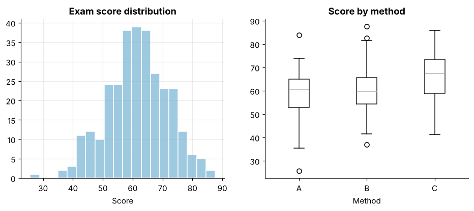

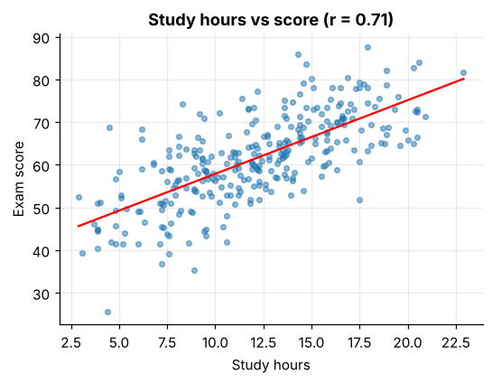